# WB - Praca domowa 1

autor: Paulina Przybyłek

```python
import numpy as np
import pandas as pd
import dalex as dx
import pickle
from sklearn.metrics import accuracy_score
import warnings
warnings.filterwarnings('ignore')
```

## Wczytanie zbioru danych *heart* oraz modelu

Podczas EDA zbioru *heart.csv* z kaggle dokonano kodowania zmiennych kategorycznych oraz imputacji braków danych modą. Zdecydowano też, aby usunąć zmienną oldpeak, ponieważ jest ściśle skorelowana ze slope, które oznacza nachylenie tej zmiennej, więc obie odpowiadają za to samo. W tej pracy użyto tego właśnie zbioru po wprowadzonych poprawkach. Dotyczyć będzie ona wyjaśniania obserwacji ze zbioru treningowego, ponieważ to na nim uczono model.

Wykorzystywanym modelem będzie las losowy.

```python
# wczytujemy treningowy zbiór danych - na treningowym model został nauczony
data_train  = pd.read_csv('heart_train.csv')
data_train.head()
```

|  | age | sex | trestbps | chol | fbs | thalach | exang | ca | cp_0 | cp_1 | ... | thal_1 | thal_2 | thal_3 | slope_0 | slope_1 | slope_2 | restecg_0 | restecg_1 | restecg_2 | target |
| --- | --- | --- | --- | --- | --- | --- | --- | --- | --- | --- | --- | --- | --- | --- | --- | --- | --- | --- | --- | --- | --- |
| 0 | 43 | 0 | 122 | 213 | 0 | 165 | 0 | 0 | 0 | 0 | ... | 0 | 1 | 0 | 0 | 1 | 0 | 0 | 1 | 0 | 1 |
| 1 | 66 | 0 | 146 | 278 | 0 | 152 | 0 | 1 | 0 | 0 | ... | 0 | 1 | 0 | 0 | 1 | 0 | 1 | 0 | 0 | 1 |
| 2 | 58 | 1 | 140 | 211 | 1 | 165 | 0 | 0 | 0 | 0 | ... | 0 | 1 | 0 | 0 | 0 | 1 | 1 | 0 | 0 | 1 |
| 3 | 63 | 0 | 124 | 197 | 0 | 136 | 1 | 0 | 1 | 0 | ... | 0 | 1 | 0 | 0 | 1 | 0 | 0 | 1 | 0 | 0 |
| 4 | 57 | 1 | 154 | 232 | 0 | 164 | 0 | 1 | 0 | 1 | ... | 0 | 1 | 0 | 0 | 0 | 1 | 1 | 0 | 0 | 0 |

5 rows × 22 columns

```python
rf = pickle.load(open('random_forest', 'rb'))
```

## Predykcja modelu dla wybranej obserwacji ze zbioru danych

Wybrano jedną obserwację ze zbioru i na niej sprawdzono predykcję modelu.

```python
target_train = data_train.target.values
data_train = data_train.drop(['target'], axis = 1)
```

```python
observation = data_train.loc[[11], :]
print('Predykcja: ', rf.predict(observation)[0], 'Prawdziwa wartość: ', target_train[11])
```

```
Predykcja:  1 Prawdziwa wartość:  1
```

Jest to pacjent chory.

```python
observation
```

|  | age | sex | trestbps | chol | fbs | thalach | exang | ca | cp_0 | cp_1 | ... | cp_3 | thal_1 | thal_2 | thal_3 | slope_0 | slope_1 | slope_2 | restecg_0 | restecg_1 | restecg_2 |
| --- | --- | --- | --- | --- | --- | --- | --- | --- | --- | --- | --- | --- | --- | --- | --- | --- | --- | --- | --- | --- | --- |
| 11 | 56 | 1 | 120 | 240 | 0 | 169 | 0 | 0 | 0 | 1 | ... | 0 | 0 | 1 | 0 | 1 | 0 | 0 | 0 | 1 | 0 |

1 rows × 21 columns

Obserwacja dotyczy mężczyzny lat 56, z podwyższonym cholesterolem, z niedrożnymi naczyniami głównymi, atypową dławicą piersiową oraz naprawioną wadą serca (obserwuje się przepływ krwi, ale nie jest to normalne), nachylonym odcinkiem ST i normalnym wynikiem EKG. Z tymi objawami, mężczyzna jest chory.

## Dekompozycja predykcji modelu dla wybranej obserwacji

```python
# tworzymy explainer korzystając z pakietu dalex
explainer = dx.Explainer(rf, data_train, target_train)
```

```
Preparation of a new explainer is initiated

  -> data              : 242 rows 21 cols
  -> target variable   : 242 values
  -> model_class       : sklearn.ensemble._forest.RandomForestClassifier (default)
  -> label             : Not specified, model's class short name will be used. (default)
  -> predict function  : <function yhat_proba_default at 0x7f2e054f6ae8> will be used (default)
  -> predict function  : Accepts pandas.DataFrame and numpy.ndarray.
  -> predicted values  : min = 0.0, mean = 0.543, max = 1.0
  -> model type        : classification will be used (default)
  -> residual function : difference between y and yhat (default)
  -> residuals         : min = -0.36, mean = -0.00165, max = 0.39
  -> model_info        : package sklearn

A new explainer has been created!
```

Policzono poniżej jeszcze predykcję dla wybranej zmiennej za pomocą utworzonego explainera.

```python
explainer.predict(observation)[0]
```

```
0.93
```

Teraz można przejść do wyjaśniania metodami Break Down oraz Shapley.

### Break Down

```python
pp = explainer.predict_parts(observation)
pp.plot()
```

[interactive chart not shown]

Zero naczyń głównych zabarwionych fluoroskopią, czyli naczynia są niedrożne, jest głównym czynnikiem decydującym o chorobie serca. Następnie jest zmienna, która oznacza, że występowanie jakiegoś bólu klatki związanego z jakimś schorzeniem, a potem zmienna określająca naprawioną wadę serca. One decydują za chorobą, co ma sens, aby osoba z bólem klatki i niedrożnością naczyń była chora. Natomiast bycie mężczyzną ma negatywny wpływ, czyli przejawia bardziej za brakiem choroby serca (wiadomo z EDA, że to kobiety chorują częściej).

Poniżej można zobaczyć tabelę dla tej metody i pozycję wszystkich zmiennych, nawet tych co nie są pokazane na wykresie.

```python
pp
```

|  | variable_name | variable_value | variable | cumulative | contribution | sign | position | label |
| --- | --- | --- | --- | --- | --- | --- | --- | --- |
| 0 | intercept | 1 | intercept | 0.542975 | 0.542975 | 1.0 | 22 | RandomForestClassifier |
| 1 | ca | 0.0 | ca = 0.0 | 0.635000 | 0.092025 | 1.0 | 21 | RandomForestClassifier |
| 2 | cp_0 | 0.0 | cp_0 = 0.0 | 0.683554 | 0.048554 | 1.0 | 20 | RandomForestClassifier |
| 3 | thal_2 | 1.0 | thal_2 = 1.0 | 0.734752 | 0.051198 | 1.0 | 19 | RandomForestClassifier |
| 4 | sex | 1.0 | sex = 1.0 | 0.690950 | -0.043802 | -1.0 | 18 | RandomForestClassifier |
| 5 | thalach | 169.0 | thalach = 169.0 | 0.741777 | 0.050826 | 1.0 | 17 | RandomForestClassifier |
| 6 | exang | 0.0 | exang = 0.0 | 0.764669 | 0.022893 | 1.0 | 16 | RandomForestClassifier |
| 7 | thal_3 | 0.0 | thal_3 = 0.0 | 0.797314 | 0.032645 | 1.0 | 15 | RandomForestClassifier |
| 8 | slope_1 | 0.0 | slope_1 = 0.0 | 0.837810 | 0.040496 | 1.0 | 14 | RandomForestClassifier |
| 9 | cp_1 | 1.0 | cp_1 = 1.0 | 0.852314 | 0.014504 | 1.0 | 13 | RandomForestClassifier |
| 10 | slope_2 | 0.0 | slope_2 = 0.0 | 0.842479 | -0.009835 | -1.0 | 12 | RandomForestClassifier |
| 11 | cp_2 | 0.0 | cp_2 = 0.0 | 0.840992 | -0.001488 | -1.0 | 11 | RandomForestClassifier |
| 12 | chol | 240.0 | chol = 240.0 | 0.865372 | 0.024380 | 1.0 | 10 | RandomForestClassifier |
| 13 | trestbps | 120.0 | trestbps = 120.0 | 0.863099 | -0.002273 | -1.0 | 9 | RandomForestClassifier |
| 14 | restecg_0 | 0.0 | restecg_0 = 0.0 | 0.874380 | 0.011281 | 1.0 | 8 | RandomForestClassifier |
| 15 | slope_0 | 1.0 | slope_0 = 1.0 | 0.862107 | -0.012273 | -1.0 | 7 | RandomForestClassifier |
| 16 | age | 56.0 | age = 56.0 | 0.922438 | 0.060331 | 1.0 | 6 | RandomForestClassifier |
| 17 | restecg_1 | 1.0 | restecg_1 = 1.0 | 0.925620 | 0.003182 | 1.0 | 5 | RandomForestClassifier |
| 18 | cp_3 | 0.0 | cp_3 = 0.0 | 0.930455 | 0.004835 | 1.0 | 4 | RandomForestClassifier |
| 19 | thal_1 | 0.0 | thal_1 = 0.0 | 0.931322 | 0.000868 | 1.0 | 3 | RandomForestClassifier |
| 20 | restecg_2 | 0.0 | restecg_2 = 0.0 | 0.931488 | 0.000165 | 1.0 | 2 | RandomForestClassifier |
| 21 | fbs | 0.0 | fbs = 0.0 | 0.930000 | -0.001488 | -1.0 | 1 | RandomForestClassifier |
| 22 |  |  | prediction | 0.930000 | 0.930000 | 1.0 | 0 | RandomForestClassifier |

### SHAP

```python
pp_shap = explainer.predict_parts(observation, type='shap')
pp_shap.plot()
```

[interactive chart not shown]

W porównaniu z metodą Break Down, tutaj widać, że wiek 56 lat ma wpływ na bycie chorym, chociaż wcześniej jego pozycja była na tyle niska, że nie wystąpiła na wykresie. Wpływ negatywny zachowała płeć.

Warto porównać te dwie metody, ponieważ zmieniła się kolejność niektórych zmiennych (po uśrednieniu tych wpływów część zmiennych np. thalach podskoczyła w rankingu). Zmienna ca nadal zachowała pozycję zmiennej o najważniejszym wpływie na chorobę.

Poniżej tabela dla SHAP, jest podobna do poprzedniej, ale nie mówi o pozycji co jest zrozumiałe.

```python
pp_shap
```

|  | variable | contribution | variable_name | variable_value | sign | label | B |
| --- | --- | --- | --- | --- | --- | --- | --- |
| 0 | thal_2 = 1.0 | 0.054050 | thal_2 | 1 | 1.0 | RandomForestClassifier | 1 |
| 1 | restecg_0 = 0.0 | 0.004174 | restecg_0 | 0 | 1.0 | RandomForestClassifier | 1 |
| 2 | restecg_2 = 0.0 | 0.000620 | restecg_2 | 0 | 1.0 | RandomForestClassifier | 1 |
| 3 | fbs = 0.0 | -0.000785 | fbs | 0 | -1.0 | RandomForestClassifier | 1 |
| 4 | cp_3 = 0.0 | 0.000207 | cp_3 | 0 | 1.0 | RandomForestClassifier | 1 |
| ... | ... | ... | ... | ... | ... | ... | ... |
| 16 | restecg_1 = 1.0 | 0.001527 | restecg_1 | 1 | 1.0 | RandomForestClassifier | 0 |
| 17 | thal_1 = 0.0 | 0.001387 | thal_1 | 0 | 1.0 | RandomForestClassifier | 0 |
| 18 | restecg_0 = 0.0 | 0.000777 | restecg_0 | 0 | 1.0 | RandomForestClassifier | 0 |
| 19 | restecg_2 = 0.0 | 0.000443 | restecg_2 | 0 | 1.0 | RandomForestClassifier | 0 |
| 20 | cp_3 = 0.0 | -0.000440 | cp_3 | 0 | -1.0 | RandomForestClassifier | 0 |

546 rows × 7 columns

## Wybór dwóch obserwacji o innych najważniejszych zmiennych

Zadanie polega na przyjrzeniu się obserwacjom, które mają inne zmienne najważniejsze.

### Wykresy Break Down

Zadanie dla tego modelu okazało się trudne, ponieważ zmienna **ca** występuje najczęśniej na pierwszym miejscu (dla ok. 100 przejrzanych obserwacji była na pierwszym miejscu) dla metody Break Down. Dlatego przyjrzano się zmiennym na dwóch kolejnych miejscach pod względem ważności.

```python
explainer.predict_parts(data_train.loc[[203], :]).plot()
```

[interactive chart not shown]

Dla pierwszej obserwacji największy wpływ ma maksymalne osiągnięte tętno (zmienna thalach) oraz płeć. Przy czym mają inny wpływ na bycie chorym. Jak wcześniej powiedziano, kobiety mają większe prawdopodobieństwo zachorowania, a takie średnie tętno dla młodego człowieka mogłoby coś złego znaczyć, ale że zbiór zawiera przewagę osób starszych, a oni mają na co dzień niższe tętno, to ta zmienna ma wpływ negatywny na chorobę.

```python
explainer.predict_parts(data_train.loc[[2], :]).plot()
```

[interactive chart not shown]

Dla drugiej obserwacji najważniejsze są: ból w klatce spowodowany jakimś schorzeniem (zmienna cp_0=0), naprawiona wada (zmienna thal_2=1). Jak ktoś ma ból w klatce to może to oznaczać, że jest chory. Naprawiona wada oznacza, że mogą być problemy z przepływem krwi, to może powodować choroby jak i nie, bo może się zdarzyć, że naprawiona wada będzie mieć zły skutek nadal. Obie te zmienne dla tego pacjenta mają wpływ poztywny za chorobą.

Jednak przy metodzie Break Down, pozycja ma znaczenie a dobrze byłoby znać rzeczywisty średni wpływ na predykcję dla tych pacjnetów. Poniżej sprawdzenie najważniejszych obserwacji dla metody Shapley.

```python
explainer.predict_parts(data_train.loc[[203], :], type='shap').plot()
```

[interactive chart not shown]

I teraz widać zmianę w najważniejszych zmiennych, najważniejsze są płeć, wszystkie naczynia niedrożne oraz naprawiona wada klatki. O płci już powiedziano wyżej, że bycie kobietą ma sprory wpływ na chorobę. Niedrożność naczyń oraz niekoniecznie dobry przepływ krwi również mają duże znaczenie.

```python
explainer.predict_parts(data_train.loc[[2], :], type='shap').plot()
```

[interactive chart not shown]

Tutaj najważniejsze są wszystkie naczynia niedrożne, naprawiona wada oraz występowanie jakiegoś bólu klatki mającego podłoże choroby/schorzenia jakiegoś. Względem Break Down zamieniła się kolejność thal_2 z cp_0, ale nadal trzy najważniejsze zmienne są takie same.

Porównując wykresy SHAP - 2 na 3 zmienne ze trzech najważniejszych się pokrywają, ale występują w różnej kolejności. Jednak dla pacjenta pierwszego to płeć ma znaczenie największe, a dla drugiego niedrożność naczyń.

### Wykresy SHAP

Porównano ważność zmiennych w zależności od kolejności (pozycji) i one się różniły, ale przy SHAP wystąpiły podobne. Dlatego też poniżej pokazano różne wartości dla metody Shapley.

```python
explainer.predict_parts(data_train.loc[[34], :], type='shap').plot()
```

[interactive chart not shown]

Dla metody Shapley zmienna ca spadła, za najważniejsze uznane zostały wiek, ciśnienie spoczynkowe krwi oraz maksymalne tętno. Osoby w wieku 64 mogą chorować na serce, niskie tętno często dotyczy osób starszych, którzy chorują na serce również często. Co do ciśnienia spoczynkowego to norma, ale wcale nie musi oznaczać, że jakaś choroba serca nie występuje przy takim.

```python
explainer.predict_parts(data_train.loc[[7], :], type='shap').plot()
```

[interactive chart not shown]

Tutaj najważniejsze są niedrożne naczynia, naprawiona wada i płeć. Te zmienne są samo tłumaczące się za tym, czemu są ważne (ale też już wyjaśniliśmy je w innych przykładach).

## Znaleznie dwóch obserwacji ze zbioru danych, które mają dla tych samych zmiennych inne efekty

### Wpływ jednej zmiennej z inną wartością

Poniżej metoda Break Down dla dwóch różnych obserwacji.

```python
explainer.predict_parts(data_train.loc[[98], :]).plot()
```

[interactive chart not shown]

```python
explainer.predict_parts(data_train.loc[[135], :]).plot()
```

[interactive chart not shown]

Interesującą zmienną jest płeć, tutaj jest to kobieta, która ma wszystkie naczynia niedrożne, brak bólu w klatce bez powodu (czyli ma ból z jakimś powodem, czyli atypową dławicę piersiową, co widzimy na 5 miejscu od góry), ma odracalną wadę serca itp. Natomiast w pierwszej obserwacji był mężczyzna o takich samych pierwszych zmiennych (wartości ca, cp_0, thal_2). Można zauważyć, jak bycie kobietą mocno wpływa na występowanie choroby, kiedy to bycie mężczyzną przejawia za jej brakiem.

### Wpływ jednej zmiennej z tą samą wartością, ale występującej w innej kolejności ważności zmiennych

Wybrano dwie obserwacje, które mają takie same wartości zmiennych (pomijamy ciągłe, bo one się różnią). Zobaczyć je można poniżej w tabeli.

```python
data_train.iloc[[162, 217]]
```

|  | age | sex | trestbps | chol | fbs | thalach | exang | ca | cp_0 | cp_1 | ... | cp_3 | thal_1 | thal_2 | thal_3 | slope_0 | slope_1 | slope_2 | restecg_0 | restecg_1 | restecg_2 |
| --- | --- | --- | --- | --- | --- | --- | --- | --- | --- | --- | --- | --- | --- | --- | --- | --- | --- | --- | --- | --- | --- |
| 162 | 57 | 1 | 130 | 131 | 0 | 115 | 1 | 1 | 1 | 0 | ... | 0 | 0 | 0 | 1 | 0 | 1 | 0 | 0 | 1 | 0 |
| 217 | 57 | 1 | 152 | 274 | 0 | 88 | 1 | 1 | 1 | 0 | ... | 0 | 0 | 0 | 1 | 0 | 1 | 0 | 0 | 1 | 0 |

2 rows × 21 columns

Jednak to ciągłe zmienne mają wpływ na stan zdrowia pacjenta i na uporządkowanie wpływowych zmiennnych w metodzie Break Down, co widać poniżej.

```python
explainer.predict_parts(data_train.loc[[162], :]).plot()
```

[interactive chart not shown]

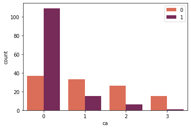

```python
import seaborn as sns
sns.countplot(data=data_train, x='ca', hue=target_train, palette='rocket_r')
```

Dekompozycja dla zmiennych opisujących drugiego pana:

```python
explainer.predict_parts(data_train.loc[[217], :]).plot()
```

[interactive chart not shown]

Tutaj są podobne zmienne co wyżej i rozumienie ich jest takie samo. Interesującą zmienną jest exang, czyli przypominając jest to występowanie dławicy wysiłkowowej (1 = tak, 0 = nie). Dla pierwszej obserwacji exang jest 7 najważniejszy a dla drugiej 8. Ważniejsze okazało się tam trestbps - spoczynkowe ciśnienie krwi, a reszta zmiennych mimo innej kolejności się powtarza. Jednak po takim uporządkowaniu dla pierwszej obserwacji exang ma negatywny wpływ, a dla drugiej pozytywny. Najwyraźniej średnia tej kolumny jest wyższa niż aktualnie uzyskana, dlatego nastąpił wzrost.

Tutaj znaczenie ma kolejność zmiennych, dlatego warto dodatkowo spojrzeć na wartości wpływów uzyskanych przez metodę Shapley, która pokazuje średni wpływ patrząc na wszystkie możliwe kolejności.

```python
explainer.predict_parts(data_train.loc[[217], :], type='shap').plot()
```

[interactive chart not shown]

I tak exang ma negatywny wpływ jak dla pierwszej, tylko tym razem jego wystąpienie jako 8 spowodowało lekki przyrost, bo średnia była większa niż aktualnie uzyskana na obserwacji.